# Practical Homework 2: Support Vector Classification

```r
library(Matrix)
library(ggplot2)
library(dplyr)
library(tidyverse)
library(e1071)
set.seed(1)

disease_data <- read.csv("https://raw.githubusercontent.com/JesseLoi/Support_Vector_Machine_Disease_Classification/main/nhis_2022.csv")
```

Let’s investigate diabetes. Let’s start by checking the different levels for diabetes.

```r
unique(disease_data$DIABETICEV)
```

```
## [1] 1 2 7 9
```

We see that our data has a yes option, a no option, and two unanswered options. We just have to worry about the yes and no options. Let’s try and filter out 7 and 9, which correspond to NA.

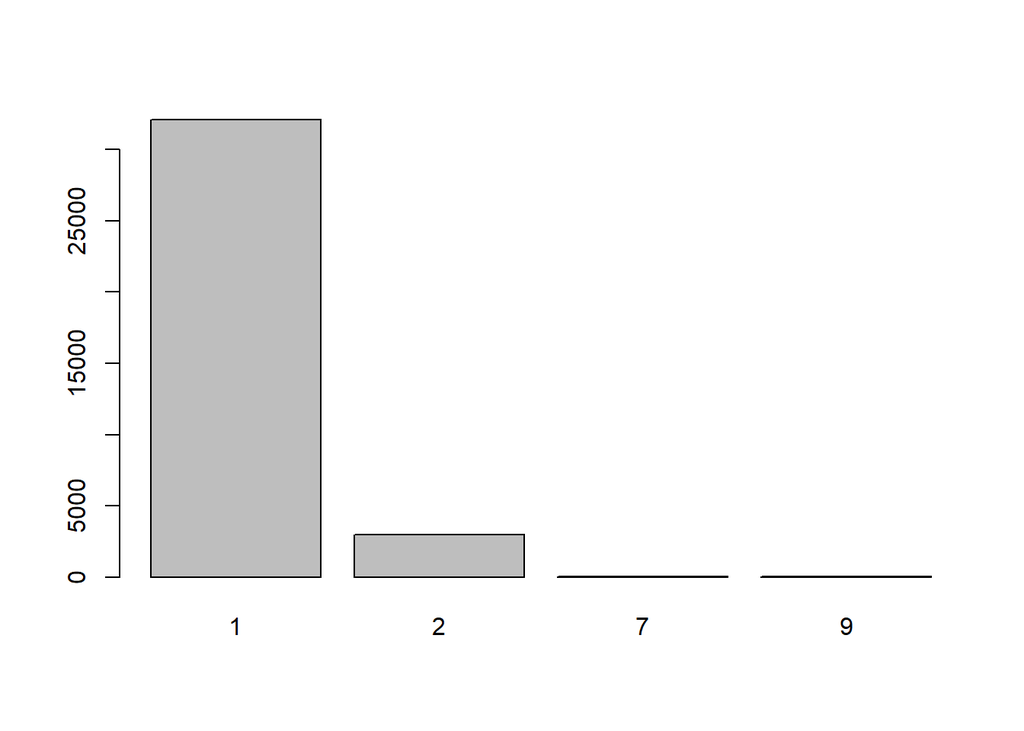

```r
plot(factor(disease_data$DIABETICEV))
```

We’ve got an overwhelming number of 1s.

Let’s consider how to resolve this.We might just consider classification error first when move onto something like precision or recall.

But let’s consider downsizing our dataset first. Let’s check some numbers.

```r
diabetes <- subset(disease_data, DIABETICEV == 2)
nrow(diabetes)
```

```
## [1] 2975
```

We’ve got around 3000 results.

Let’s check non-diabetes individuals.

```r
nondiabetes <- subset(disease_data, DIABETICEV == 1)
nrow(nondiabetes)
```

```
## [1] 32102
```

This is about 30000 results. This is a lot more. This essentially means that any algorithm aiming to correctly classify the data will have around a 90 percent success rate.

```r
diabetes_data <- disease_data %>%
  filter(DIABETICEV %in% c(1, 2))
```

Let’s check our filtering succeeded.

```r
unique(diabetes_data$DIABETICEV)
```

```
## [1] 1 2
```

```r
diabetes_data$DIABETICEV<-as.factor(diabetes_data$DIABETICEV)
```

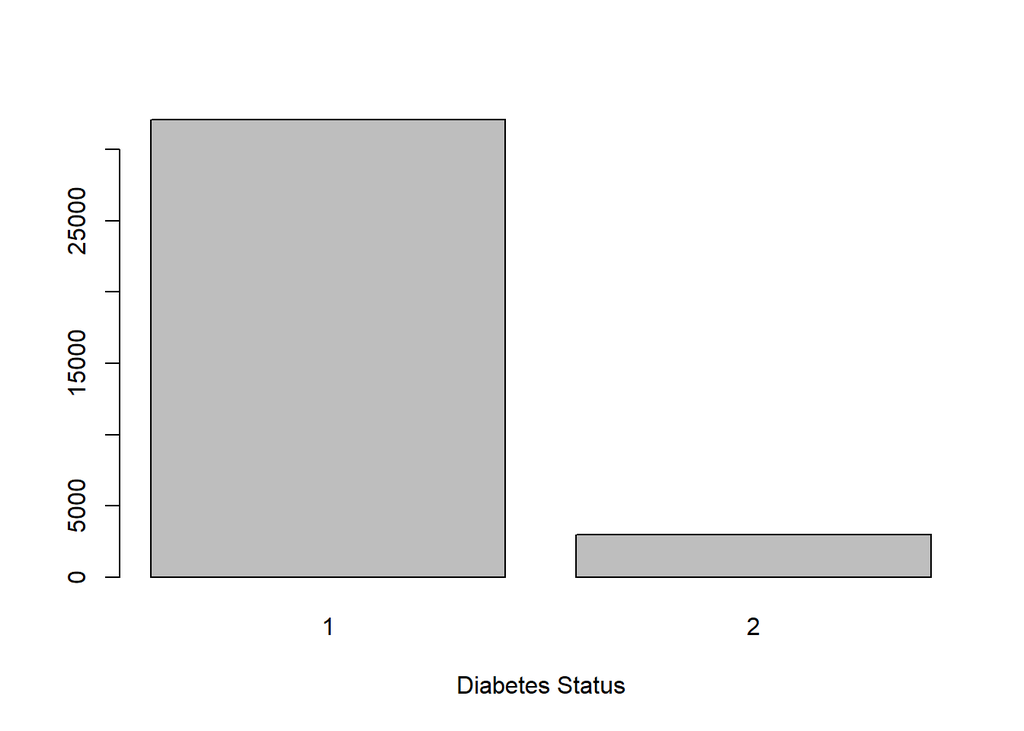

```r
plot(diabetes_data$DIABETICEV, xlab="Diabetes Status")
```

Let’s now see if we can use education level to predict it. Let’s clean education level first.

```r
unique(diabetes_data$EDUC)
```

```
##  [1] 201 301   0 505 303 400 202 103 501 302 116 999 997
```

0, 997, and 999 are all equivalent to saying NA, so we will get rid of them.

```r
diabetes_data$EDUC[diabetes_data$EDUC %in% c(0, 997, 999)] <- NA
```

Now let’s create a new factor level where we can order the levels of education.

```r
unique(diabetes_data$EDUC)
```

```
##  [1] 201 301  NA 505 303 400 202 103 501 302 116
```

Later on, we will convert education back to numeric since we are going to scale our variables. But for the sake of visualization, we keep it as categorical.

```r
diabetes_data$EDUC<-factor(diabetes_data$EDUC, levels = c(NA, 103, 116,201, 202, 301, 302, 303, 400,501,  505  ), ordered = TRUE)
```

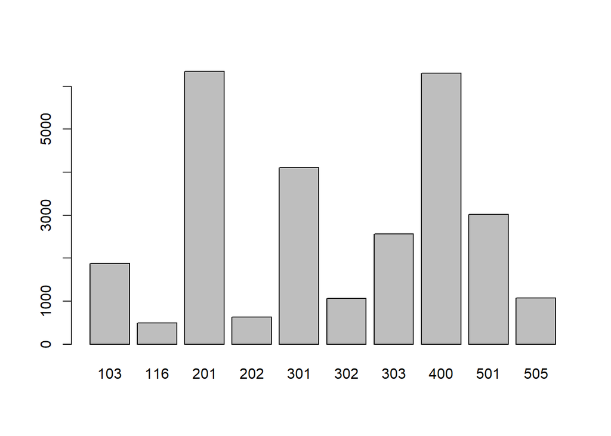

```r
plot(diabetes_data$EDUC)
```

It seems that there are the most in the high school degree and college degree holding categories, which is intuitive. It also seems that, from the data dictionary, as the number increases education level also increases.

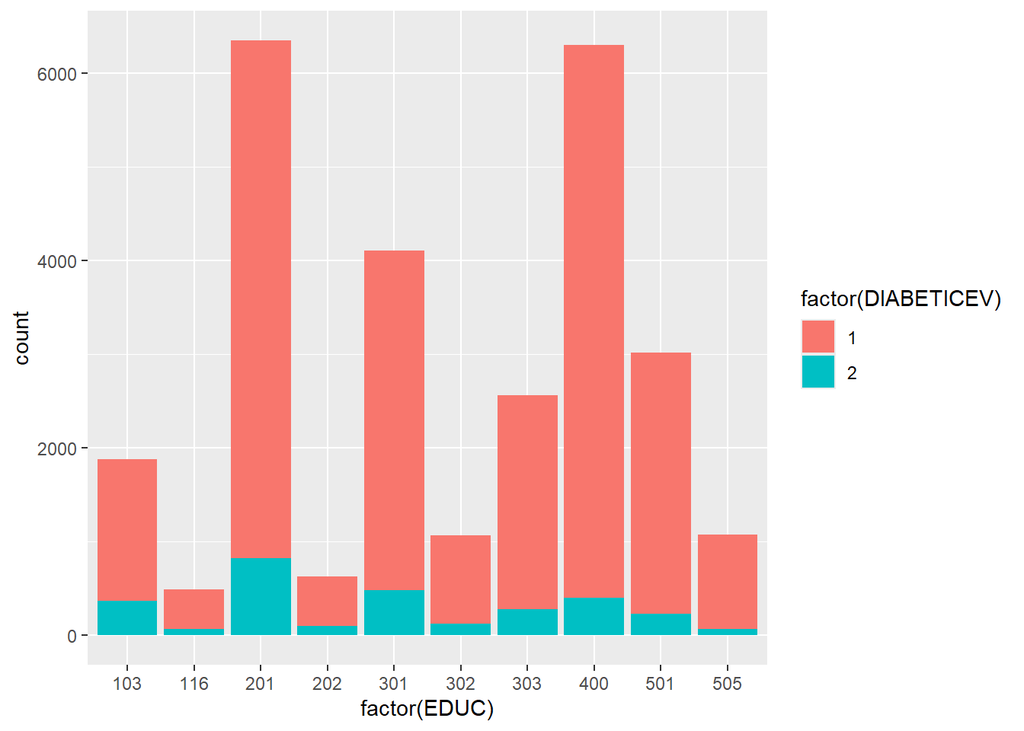

```r
diabetes_data<-na.omit(diabetes_data)

ggplot(diabetes_data, aes(x = factor(EDUC), fill = factor(DIABETICEV))) +
  geom_bar()
```

Let’s now get to cleaning the hours worked per week column.

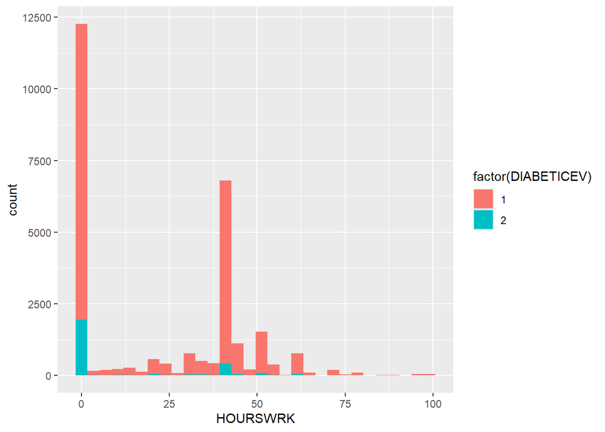

```r
ggplot(diabetes_data, aes(x = HOURSWRK, fill = factor(DIABETICEV))) +
  geom_histogram()
```

```r
unique(diabetes_data$HOURSWRK)
```

```
##  [1] 45  0  6 40 20 49 50 30 43 60 38 55  8 10 48 25  5 35 75 21 70 37 16 15 23
## [26] 97 32 80 44 18 95 52 46  3 24 61 36 62  7 29 13  1 67  9 47 99 27  4 63 58
## [51] 12 14 72 90 65 11 39 26 85 57 54 42 84 51 28 19 17 56 22 98 33 41 34  2 88
## [76] 94 76 59 68 64 53 74 71 66 91 31 83 86 77 82 87
```

Let’s set all 97, 98, and 99 to NA since those correspond with unknown values.

```r
diabetes_data$HOURSWRK[diabetes_data$HOURSWRK %in% c(97, 98, 99)] <- NA
```

Let’s look at our third variable, health insurance.

```r
unique(diabetes_data$HINOTCOVE)
```

```
## [1] 1 9 2
```

Look’s like we just have to get rid of the 9 value, which is unknown.

```r
diabetes_data$HINOTCOVE[diabetes_data$HINOTCOVE %in% c(9)] <- NA
```

Let’s look at a plot briefly.

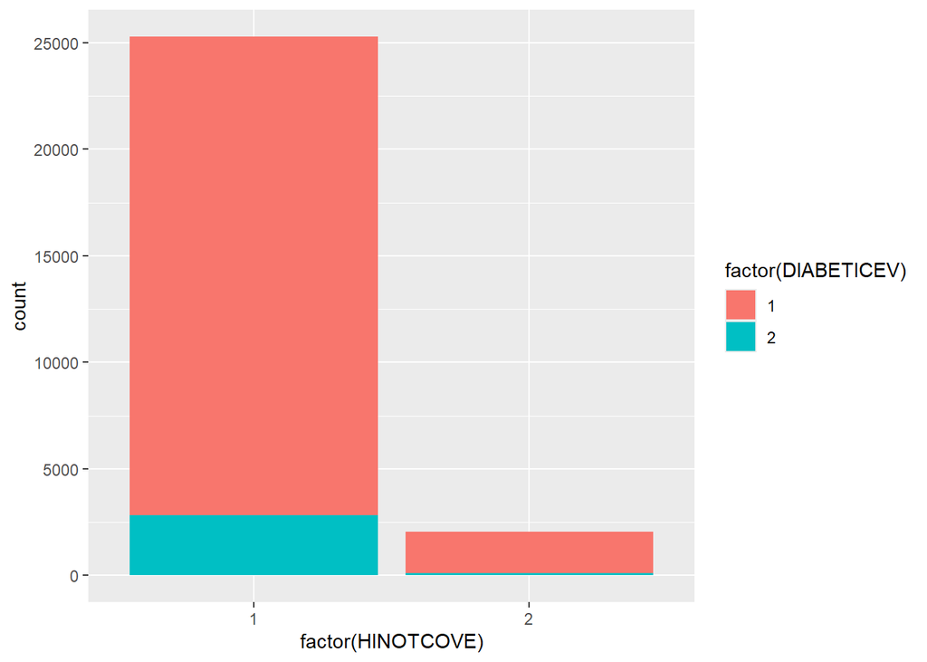

```r
diabetes_data<-na.omit(diabetes_data)

ggplot(diabetes_data, aes(x = factor(HINOTCOVE), fill = factor(DIABETICEV))) +
  geom_bar()
```

Let’s now look at and clean the data for exercise, in particular let’s see if vigorous activity has any effect on diabetes.

```r
unique(diabetes_data$VIG10DMIN)
```

```
##  [1]   0  45  60  30 120 180  90   3 150  20  15 240 360 420   5 480  75  40 600
## [20]  25  10 996  80  50   1  32 999 300  39   8  35   2 210 540  13  70   4 660
## [39] 105  33   6  37  12  44 720  22   7  43  49  65  18  17  55  61 223  21  14
## [58] 997 998   9
```

This is a numeric variable, so we can just filter out the relevant NA values, namely 000, 997, 998, and 999. We must also deal with 996 because the extreme values might interfere with our calculations since this is a numeric variable. Since we don’t know what the extreme values are, let’s set them to the maximum value of our dataset to avoid any potential leverage points. We see that 720 is the largest value.

```r
diabetes_data$VIG10DMIN[diabetes_data$VIG10DMIN %in% c(0, 997, 998, 999)] <- NA
diabetes_data$VIG10DMIN[diabetes_data$VIG10DMIN %in% c(996)] <- 720
```

```r
max(diabetes_data$VIG10DMIN[diabetes_data$VIG10DMIN < 996])
```

```
## [1] NA
```

```r
unique(diabetes_data$VIG10DMIN)
```

```
##  [1]  NA  45  60  30 120 180  90   3 150  20  15 240 360 420   5 480  75  40 600
## [20]  25  10 720  80  50   1  32 300  39   8  35   2 210 540  13  70   4 660 105
## [39]  33   6  37  12  44  22   7  43  49  65  18  17  55  61 223  21  14   9
```

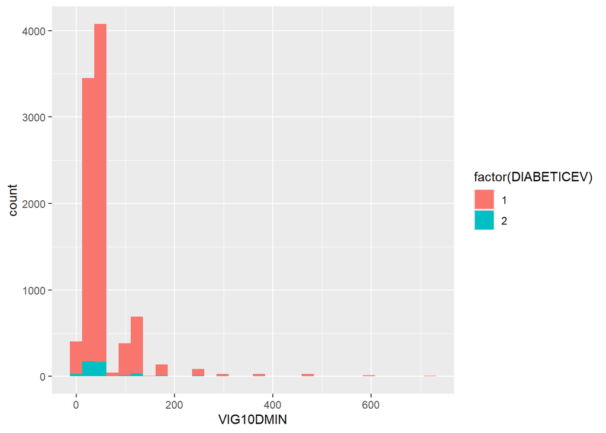

```r
ggplot(diabetes_data, aes(x = VIG10DMIN, fill = factor(DIABETICEV))) +
  geom_histogram()
```

As our fifth variable, let’s check out the diets, namely their consumption of salads.

```r
unique(diabetes_data$SALADSNO)
```

```
##  [1]  10   1   4   5   3   2   0 998   7  20   6  15  30  12   8 999  25 997  16
## [20]  28  35  14  21  19  11  24  22  17  23  27  18  13   9  60  57  26  75  36
## [39]  32
```

```r
diabetes_data$SALADSNO[diabetes_data$SALADSNO %in% c(996, 997, 998, 999)] <- NA
```

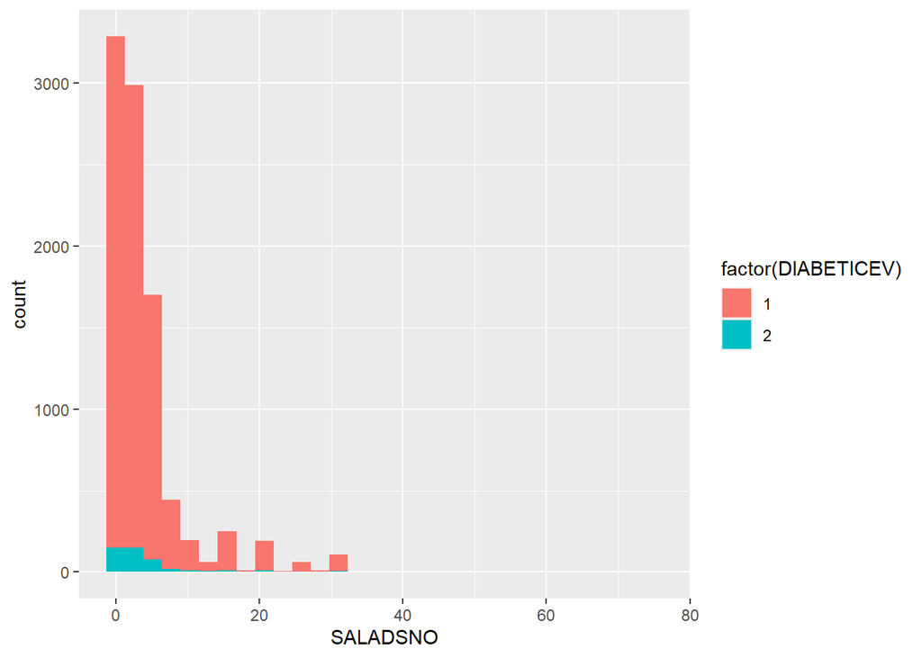

```r
diabetes_data<-na.omit(diabetes_data)
ggplot(diabetes_data, aes(x = SALADSNO, fill = factor(DIABETICEV))) +
  geom_histogram()
```

Now that we have all 5 of our variables, we can make use of our support vector machine.

Let’s create our training and test splits.

```r
#Remove all NA values one more time

diabetes_data<-na.omit(diabetes_data)

samp<-sample(1:nrow(diabetes_data),nrow(diabetes_data)/2)

train<-diabetes_data[samp,]

test<-diabetes_data[-samp,]

#Let's clean out any NA values from the train and test

train<-na.omit(train)

test<-na.omit(test)
```

```r
svmdiabetes<-svm(DIABETICEV ~SALADSNO+ VIG10DMIN+HINOTCOVE+HOURSWRK+EDUC, data=train, kernel="linear", cost=0.01, scale=TRUE)

summary(svmdiabetes)
```

```
##
## Call:
## svm(formula = DIABETICEV ~ SALADSNO + VIG10DMIN + HINOTCOVE + HOURSWRK +
##     EDUC, data = train, kernel = "linear", cost = 0.01, scale = TRUE)
##
##
## Parameters:
##    SVM-Type:  C-classification
##  SVM-Kernel:  linear
##        cost:  0.01
##
## Number of Support Vectors:  412
##
##  ( 211 201 )
##
##
## Number of Classes:  2
##
## Levels:
##  1 2
```

Let’s try making some predictions.

```r
pred_train<-predict(svmdiabetes,train, type="response")
table(pred_train, train$DIABETICEV)
```

```
##
## pred_train    1    2
##          1 4453  201
##          2    0    0
```

Here, we see that we are completely predicting non-diabetic, which is an issue.

Let’s check the test error.

```r
pred_test<-predict(svmdiabetes , test, type="response")
table(pred_test, test$DIABETICEV)
```

```
##
## pred_test    1    2
##         1 4423  232
##         2    0    0
```

```r
0/(0+232)
```

```
## [1] 0
```

Let’s try downsizing.

```r
diabetes <- subset(diabetes_data, DIABETICEV == 2)
nrow(diabetes)
```

```
## [1] 433
```

We’ve got around 433 results.

Let’s check non-diabetes individuals.

```r
nondiabetes <- subset(diabetes_data, DIABETICEV == 1)
nrow(nondiabetes)
```

```
## [1] 8876
```

This is about 8876 results. This is a lot more. But, problematically, this isn’t as much data as we first desired. However, this was likely due to getting rid of so many NA values.

I propose we downsize our non-diabetes data to match the diabetes data. However, this will have the negative drawback of leaving us with an extremely small amount of data.

```r
samp<-sample(1:nrow(nondiabetes),nrow(diabetes)*1.15, replace=FALSE)
nondiabetes2<-nondiabetes[samp,]
```

```r
data<-rbind(diabetes, nondiabetes2)
```

```r
diabetes_data2<-data
```

Let’s prepare our data for SVM.

```r
#Remove all NA values on more time

diabetes_data2<-na.omit(diabetes_data2)

diabetes_data2$EDUC<-as.numeric(diabetes_data2$EDUC)

diabetes_data2<-diabetes_data2[,c("DIABETICEV", "SALADSNO", "VIG10DMIN",
"HINOTCOVE", "HOURSWRK", "EDUC")]

#We're going to scale the numeric data here.

scale_columns <- scale(diabetes_data2[, c("SALADSNO", "VIG10DMIN", "HOURSWRK", "EDUC")])
diabetes_data2[, c("SALADSNO", "VIG10DMIN", "HOURSWRK", "EDUC")] <- scale_columns
```

```r
samp<-sample(1:nrow(diabetes_data2),nrow(diabetes_data2)/2)

train<-diabetes_data2[samp,]

test<-diabetes_data2[-samp,]

#Let's clean out any NA values from the train and test

train<-na.omit(train)

test<-na.omit(test)
```

```r
svmdiabetes2<-svm(DIABETICEV ~SALADSNO+ VIG10DMIN+HINOTCOVE+HOURSWRK+EDUC, data=train, kernel="linear", cost=0.01, scale=TRUE)

summary(svmdiabetes2)
```

```
##
## Call:
## svm(formula = DIABETICEV ~ SALADSNO + VIG10DMIN + HINOTCOVE + HOURSWRK +
##     EDUC, data = train, kernel = "linear", cost = 0.01, scale = TRUE)
##
##
## Parameters:
##    SVM-Type:  C-classification
##  SVM-Kernel:  linear
##        cost:  0.01
##
## Number of Support Vectors:  422
##
##  ( 210 212 )
##
##
## Number of Classes:  2
##
## Levels:
##  1 2
```

```r
pred_test<-predict(svmdiabetes2 , test, type="response")
table(pred_test, test$DIABETICEV)
```

```
##
## pred_test   1   2
##         1 172 106
##         2  82 105
```

```r
t<-table(pred_test, test$DIABETICEV)
sum(diag(t))/sum(t)
```

```
## [1] 0.5956989
```

This isn’t a very good accuracy rate. It’s also made worse by the fact that, from above, we had too many support vectors.

Let’s take some plots.

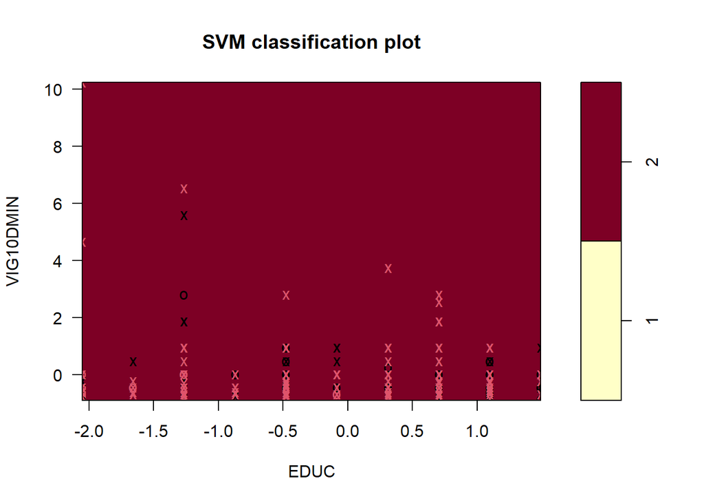

```r
plot(svmdiabetes2, train, VIG10DMIN ~ EDUC)
```

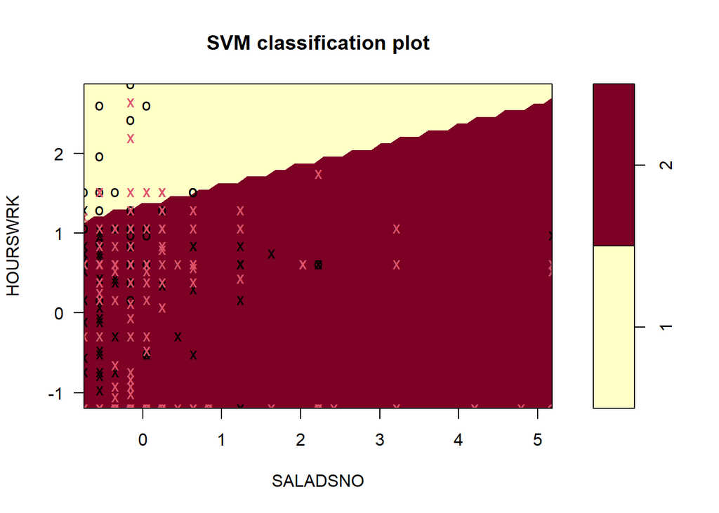

```r
plot(svmdiabetes2, train, HOURSWRK ~ SALADSNO)
```

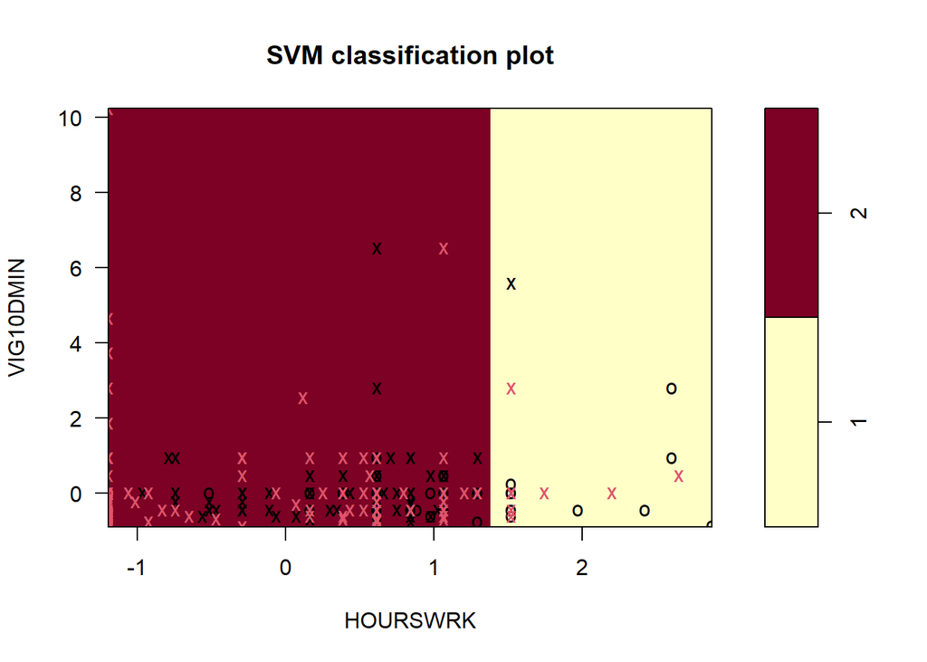

```r
plot(svmdiabetes2, train, VIG10DMIN ~ HOURSWRK)
```

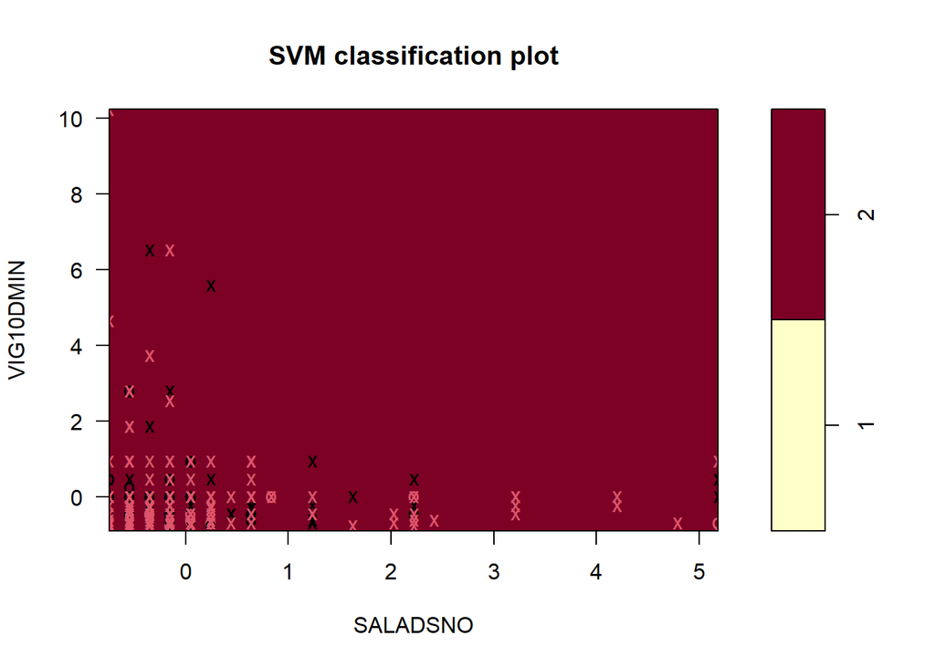

```r
plot(svmdiabetes2, train, VIG10DMIN ~ SALADSNO)
```

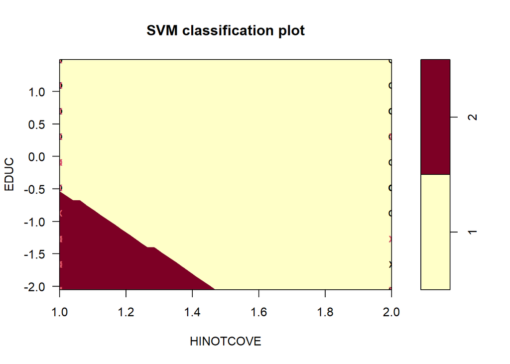

```r
plot(svmdiabetes2, train, EDUC ~ HINOTCOVE)
```

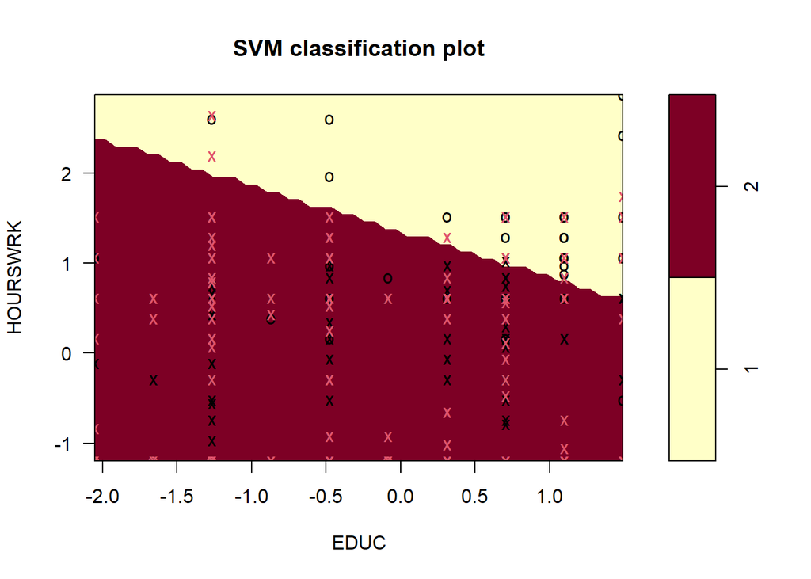

```r
plot(svmdiabetes2, train, HOURSWRK ~ EDUC)
```

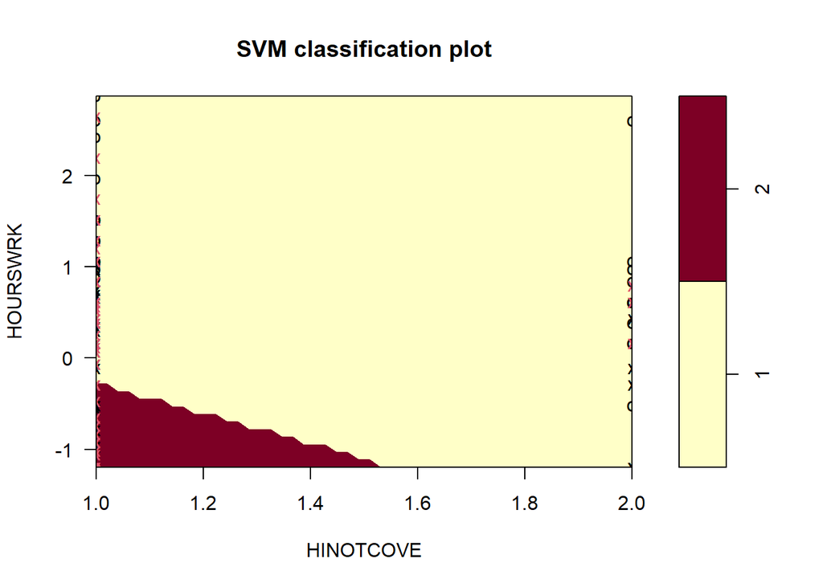

```r
plot(svmdiabetes2, train, HOURSWRK ~ HINOTCOVE)
```

We don’t have many good plots, except for the second to last one. There, we see that more hours of work and more education leads to lower rates of diabetes. This might make sense, given that working more might lead to higher levels of activity. But, as we will see, sometimes lower levels of work lead to lower rates of diabetes.

Let’s try using the tune function.

```r
tune.out <- tune(svm, DIABETICEV ~SALADSNO+ VIG10DMIN+HINOTCOVE+HOURSWRK+EDUC , data = train, kernel = "linear",
    ranges = list(cost = c(0.01, 0.05, 0.1, 1, 5, 10)))
```

```r
summary(tune.out)
```

```
##
## Parameter tuning of 'svm':
##
## - sampling method: 10-fold cross validation
##
## - best parameters:
##  cost
##  0.01
##
## - best performance: 0.3421369
##
## - Detailed performance results:
##    cost     error dispersion
## 1  0.01 0.3421369 0.08402842
## 2  0.05 0.3660037 0.08603230
## 3  0.10 0.3639223 0.09283394
## 4  1.00 0.3660500 0.09302103
## 5  5.00 0.3660500 0.09302103
## 6 10.00 0.3660500 0.09302103
```

```r
svmdiabetes2<-svm(DIABETICEV ~SALADSNO+ VIG10DMIN+HINOTCOVE+HOURSWRK+EDUC, data=train, kernel="linear", cost=0.01, scale=TRUE)

summary(svmdiabetes2)
```

```
##
## Call:
## svm(formula = DIABETICEV ~ SALADSNO + VIG10DMIN + HINOTCOVE + HOURSWRK +
##     EDUC, data = train, kernel = "linear", cost = 0.01, scale = TRUE)
##
##
## Parameters:
##    SVM-Type:  C-classification
##  SVM-Kernel:  linear
##        cost:  0.01
##
## Number of Support Vectors:  422
##
##  ( 210 212 )
##
##
## Number of Classes:  2
##
## Levels:
##  1 2
```

```r
pred_test<-predict(svmdiabetes2 , test, type="response")
table(pred_test, test$DIABETICEV)
```

```
##
## pred_test   1   2
##         1 172 106
##         2  82 105
```

```r
t<-table(pred_test, test$DIABETICEV)
sum(diag(t))/sum(t)
```

```
## [1] 0.5956989
```

```r
lin_acc<-sum(diag(t))/sum(t)
```

This isn’t too much of an improvement.

Let’s try radial svm.

```r
svmdiabetes_rad<-svm(DIABETICEV ~SALADSNO+ VIG10DMIN+HINOTCOVE+HOURSWRK+EDUC, data=train, kernel="radial", cost=0.05, scale=TRUE)

summary(svmdiabetes_rad)
```

```
##
## Call:
## svm(formula = DIABETICEV ~ SALADSNO + VIG10DMIN + HINOTCOVE + HOURSWRK +
##     EDUC, data = train, kernel = "radial", cost = 0.05, scale = TRUE)
##
##
## Parameters:
##    SVM-Type:  C-classification
##  SVM-Kernel:  radial
##        cost:  0.05
##
## Number of Support Vectors:  446
##
##  ( 224 222 )
##
##
## Number of Classes:  2
##
## Levels:
##  1 2
```

```r
pred_test<-predict(svmdiabetes_rad , test, type="response")
table(pred_test, test$DIABETICEV)
```

[output not shown]

```r
t<-table(pred_test, test$DIABETICEV)
sum(diag(t))/sum(t)
```

```
## [1] 0.5956989
```

This is about the same accuracy.

```r
tune.out <- tune(svm, DIABETICEV ~SALADSNO+ VIG10DMIN+HINOTCOVE+HOURSWRK+EDUC , data = train, kernel = "radial",
    ranges = list(cost = c(0.01, 0.05, 0.1, 1, 5, 10)))
```

```r
summary(tune.out)
```

```
##
## Parameter tuning of 'svm':
##
## - sampling method: 10-fold cross validation
##
## - best parameters:
##  cost
##    10
##
## - best performance: 0.3373265
##
## - Detailed performance results:
##    cost     error dispersion
## 1  0.01 0.4771045 0.07548257
## 2  0.05 0.3886679 0.09639729
## 3  0.10 0.3779833 0.09591195
## 4  1.00 0.3457909 0.08936227
## 5  5.00 0.3415819 0.07278821
## 6 10.00 0.3373265 0.06395779
```

```r
svmdiabetes_rad<-svm(DIABETICEV ~SALADSNO+ VIG10DMIN+HINOTCOVE+HOURSWRK+EDUC, data=train, kernel="radial", cost=1, scale=TRUE)

summary(svmdiabetes_rad)
```

```
##
## Call:
## svm(formula = DIABETICEV ~ SALADSNO + VIG10DMIN + HINOTCOVE + HOURSWRK +
##     EDUC, data = train, kernel = "radial", cost = 1, scale = TRUE)
##
##
## Parameters:
##    SVM-Type:  C-classification
##  SVM-Kernel:  radial
##        cost:  1
##
## Number of Support Vectors:  367
##
##  ( 185 182 )
##
##
## Number of Classes:  2
##
## Levels:
##  1 2
```

```r
pred_test<-predict(svmdiabetes_rad , test, type="response")
table(pred_test, test$DIABETICEV)
```

```
##
## pred_test   1   2
##         1 164  97
##         2  90 114
```

```r
t<-table(pred_test, test$DIABETICEV)
sum(diag(t))/sum(t)
```

```
## [1] 0.5978495
```

```r
rad_acc<-sum(diag(t))/sum(t)
```

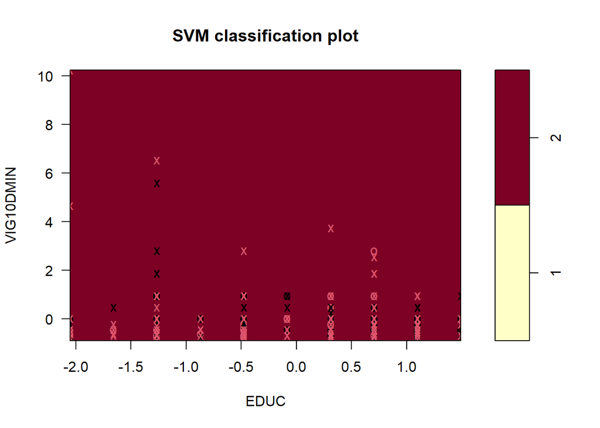

```r
plot(svmdiabetes_rad, train, VIG10DMIN ~ EDUC)
```

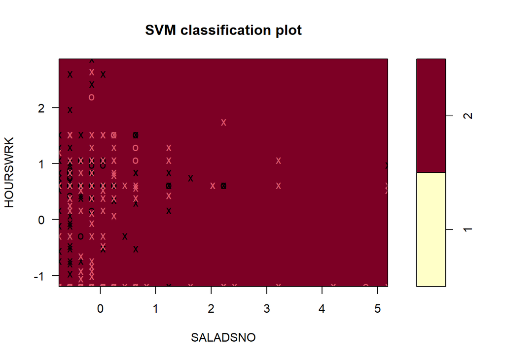

```r
plot(svmdiabetes_rad, train, HOURSWRK ~ SALADSNO)
```

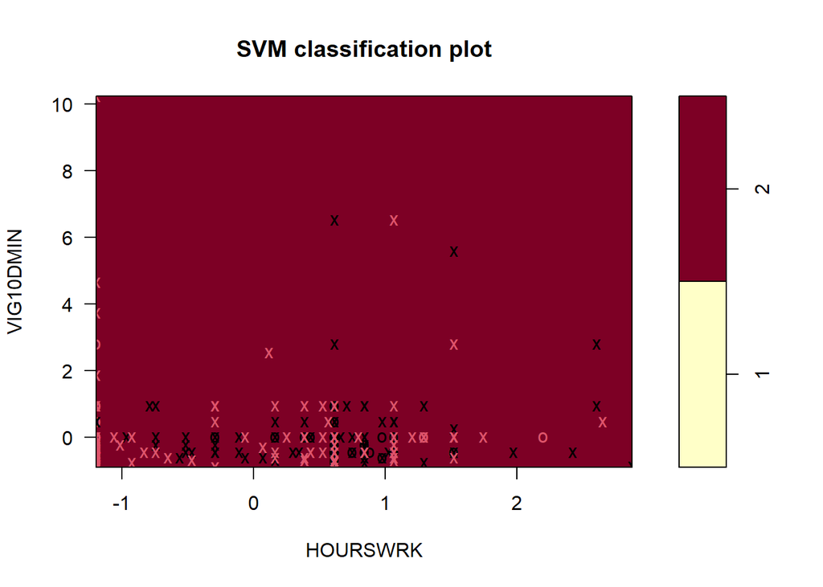

```r
plot(svmdiabetes_rad, train, VIG10DMIN ~ HOURSWRK)
```

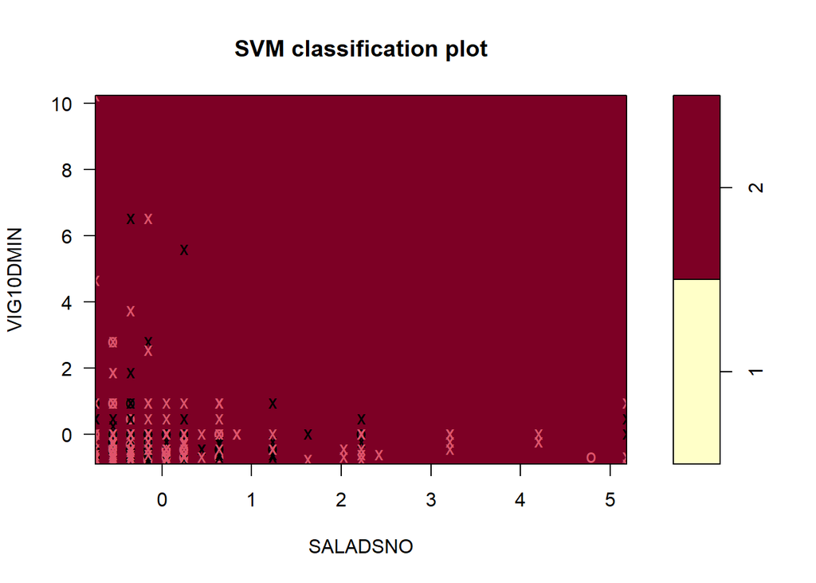

```r
plot(svmdiabetes_rad, train, VIG10DMIN ~ SALADSNO)
```

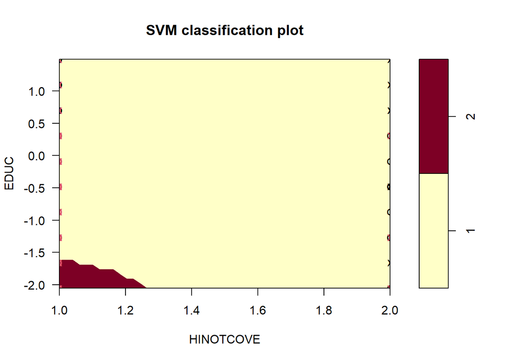

```r
plot(svmdiabetes_rad, train, EDUC ~ HINOTCOVE)
```

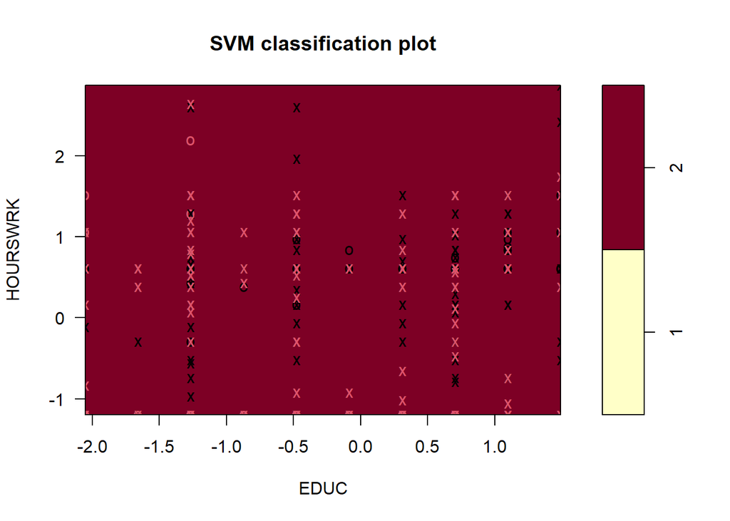

```r
plot(svmdiabetes_rad, train, HOURSWRK ~ EDUC)
```

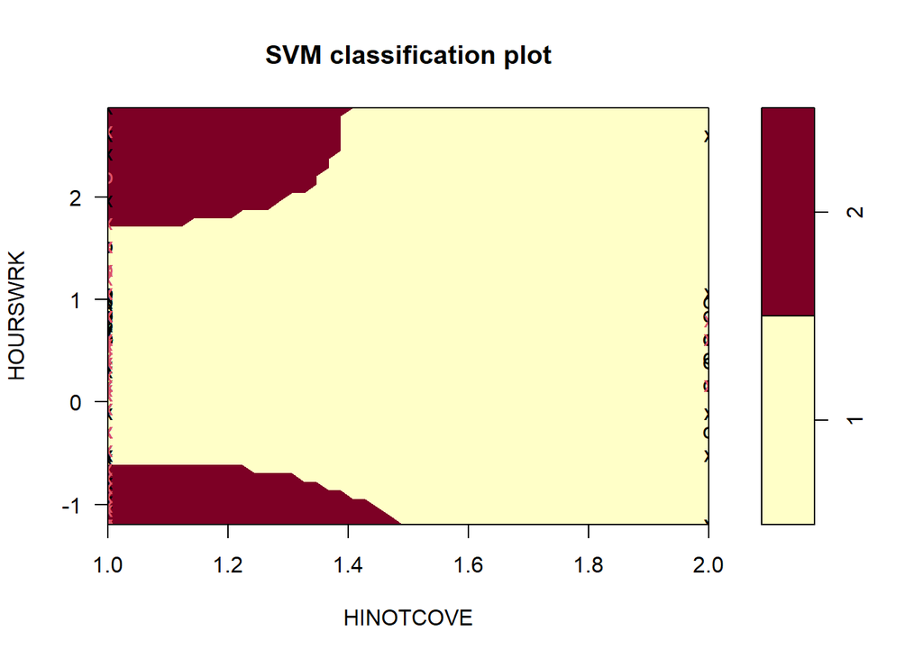

```r
plot(svmdiabetes_rad, train, HOURSWRK ~ HINOTCOVE)
```

It looks like only the last plot gives us some reasonable boundaries, but not even this one is very strong. Wee see it suggests moderate hours of work and health insurance not being covered. This is very unintuitive. It doesn’t seem to fit the data very well.

Let’s finally check polynomial svm.

```r
svmdiabetes_poly2<-svm(DIABETICEV ~SALADSNO+ VIG10DMIN+HINOTCOVE+HOURSWRK+EDUC, data=train, kernel="polynomial",degree=2, cost=0.1, scale=TRUE)

summary(svmdiabetes_poly2)
```

```
##
## Call:
## svm(formula = DIABETICEV ~ SALADSNO + VIG10DMIN + HINOTCOVE + HOURSWRK +
##     EDUC, data = train, kernel = "polynomial", degree = 2, cost = 0.1,
##     scale = TRUE)
##
##
## Parameters:
##    SVM-Type:  C-classification
##  SVM-Kernel:  polynomial
##        cost:  0.1
##      degree:  2
##      coef.0:  0
##
## Number of Support Vectors:  437
##
##  ( 218 219 )
##
##
## Number of Classes:  2
##
## Levels:
##  1 2
```

```r
pred_test<-predict(svmdiabetes_poly2 , test, type="response")
table(pred_test, test$DIABETICEV)
```

```
##
## pred_test   1   2
##         1 233 196
##         2  21  15
```

```r
t<-table(pred_test, test$DIABETICEV)
sum(diag(t))/sum(t)
```

```
## [1] 0.5333333
```

The accuracy is a bit worse.

```r
tune.out <- tune(svm, DIABETICEV ~SALADSNO+ VIG10DMIN+HINOTCOVE+HOURSWRK+EDUC , data = train, kernel = "polynomial", degree=2,
    ranges = list(cost = c(0.01, 0.05, 0.1, 1, 5, 10)))
```

```r
summary(tune.out)
```

```
##
## Parameter tuning of 'svm':
##
## - sampling method: 10-fold cross validation
##
## - best parameters:
##  cost
##     5
##
## - best performance: 0.3740981
##
## - Detailed performance results:
##    cost     error dispersion
## 1  0.01 0.5136910 0.08169968
## 2  0.05 0.5028677 0.09562750
## 3  0.10 0.4984736 0.10063175
## 4  1.00 0.4105920 0.06430288
## 5  5.00 0.3740981 0.05168297
## 6 10.00 0.3762720 0.03836173
```

```r
svmdiabetes_poly2<-svm(DIABETICEV ~SALADSNO+ VIG10DMIN+HINOTCOVE+HOURSWRK+EDUC, data=train, kernel="polynomial",degree=2, cost=5, scale=TRUE)

summary(svmdiabetes_poly2)
```

```
##
## Call:
## svm(formula = DIABETICEV ~ SALADSNO + VIG10DMIN + HINOTCOVE + HOURSWRK +
##     EDUC, data = train, kernel = "polynomial", degree = 2, cost = 5,
##     scale = TRUE)
##
##
## Parameters:
##    SVM-Type:  C-classification
##  SVM-Kernel:  polynomial
##        cost:  5
##      degree:  2
##      coef.0:  0
##
## Number of Support Vectors:  385
##
##  ( 195 190 )
##
##
## Number of Classes:  2
##
## Levels:
##  1 2
```

```r
pred_test<-predict(svmdiabetes_poly2 , test, type="response")
table(pred_test, test$DIABETICEV)
```

```
##
## pred_test   1   2
##         1 160 113
##         2  94  98
```

```r
t<-table(pred_test, test$DIABETICEV)
sum(diag(t))/sum(t)
```

```
## [1] 0.5548387
```

```r
poly2_acc<-sum(diag(t))/sum(t)
```

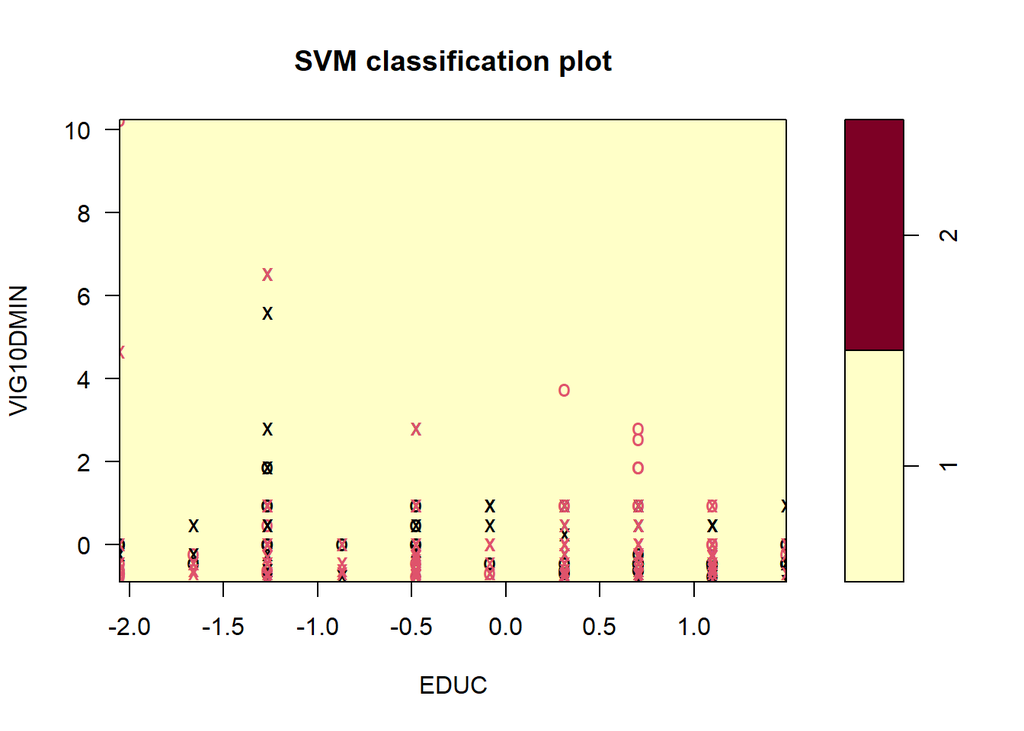

```r
plot(svmdiabetes_poly2, train, VIG10DMIN ~ EDUC)
```

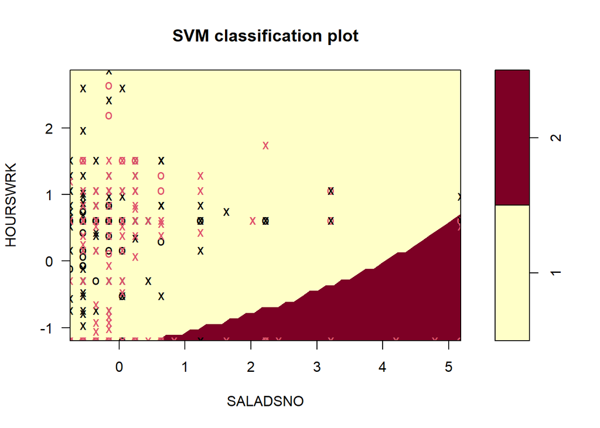

```r
plot(svmdiabetes_poly2, train, HOURSWRK ~ SALADSNO)
```

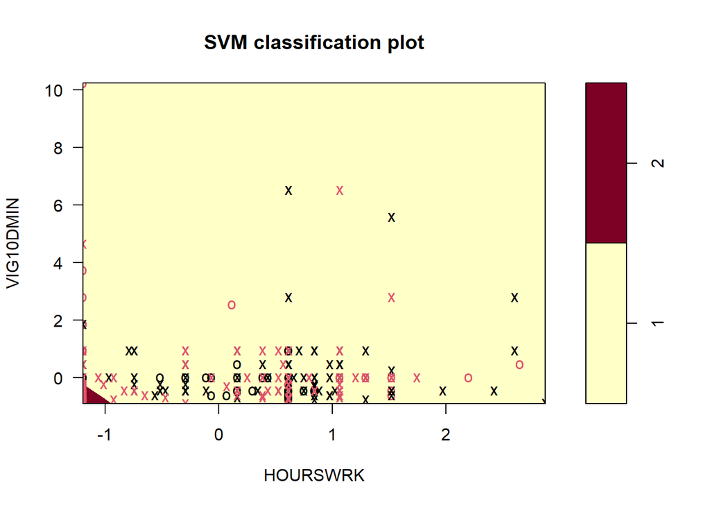

```r
plot(svmdiabetes_poly2, train, VIG10DMIN ~ HOURSWRK)
```

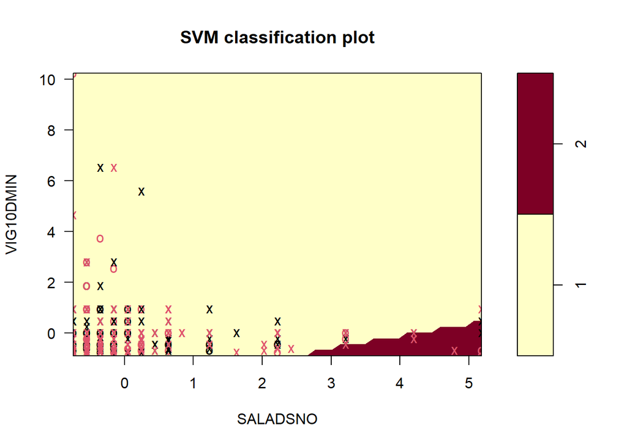

```r
plot(svmdiabetes_poly2, train, VIG10DMIN ~ SALADSNO)
```

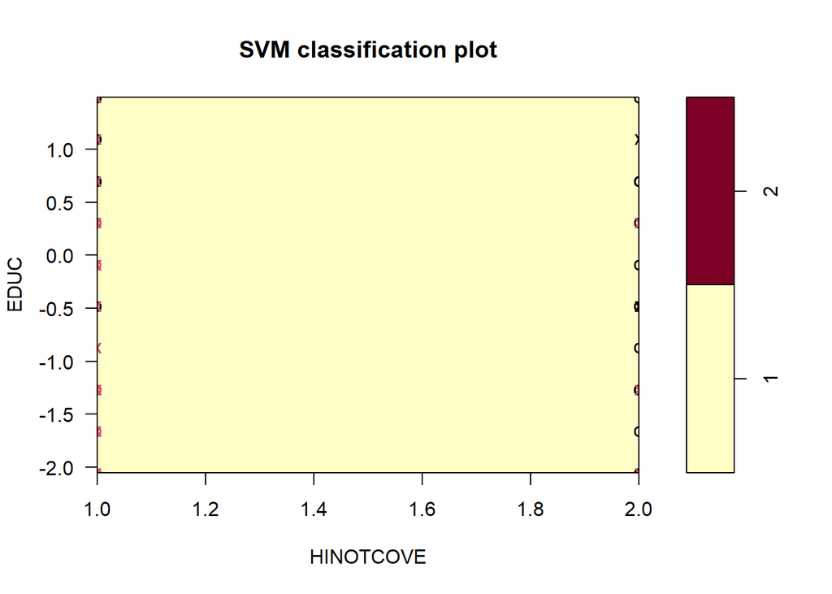

```r
plot(svmdiabetes_poly2, train, EDUC ~ HINOTCOVE)
```

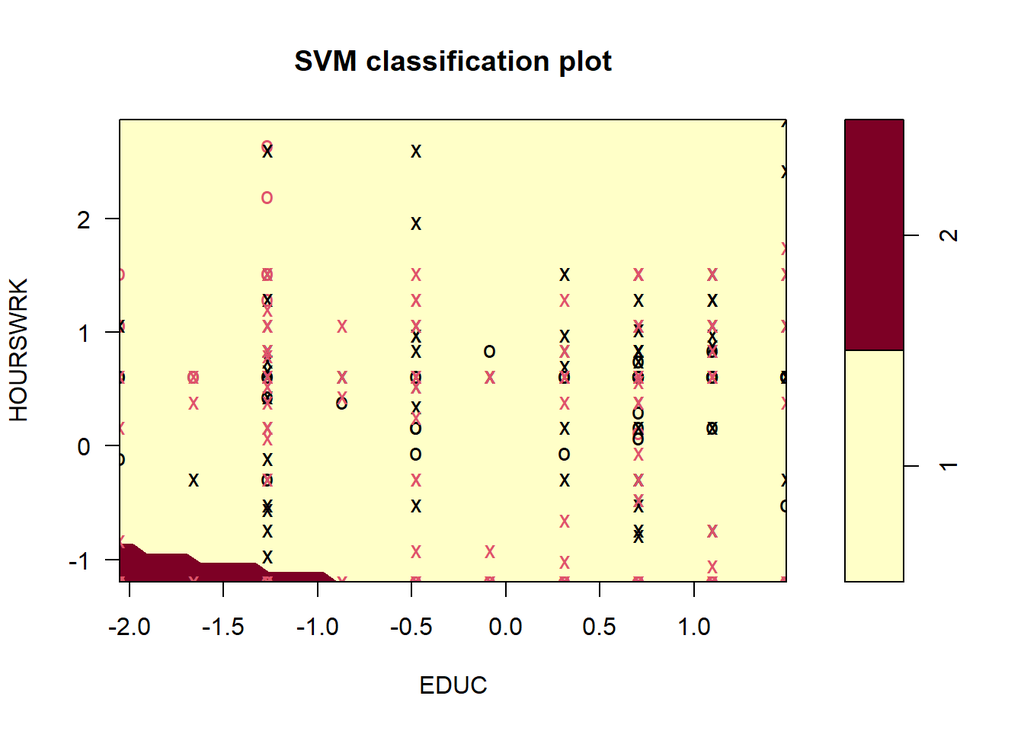

```r
plot(svmdiabetes_poly2, train, HOURSWRK ~ EDUC)
```

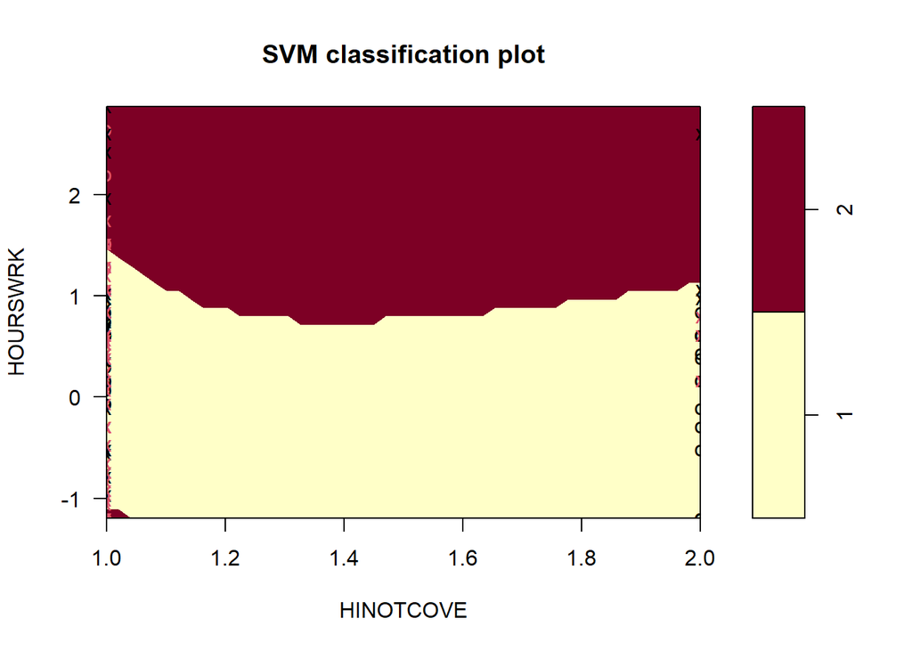

```r
plot(svmdiabetes_poly2, train, HOURSWRK ~ HINOTCOVE)
```